# A case study in linear discriminant analysis and K-means clustering

*In the following, we will use linear discriminant analysis and K-means clustering for grouping our data on housing in the Boston area. The dataset we utilize is openly available from the MASS-package in R.*

We have a somewhat similar task at our hands as with logistic regression: our purpose is to be able to sort our dataset into distinct classes. One way to do this is to predetermine the class labels, and then utilize the features in the dataset to predict those labels. This classification task is then a form of *supervised learning*, one example of which we already introduced in the above with logistic regression. Another alternative for completing a similar task is that of linear discriminant analysis, a limitation of which is that the predictors ought to be normally distributed (which also implies they must be continuous, of course).

Another approach to grouping data items is that inherent in *unsupervised learning*, where the correct class labels are not provided in the training dataset, but are instead determined by the algorithm itself, usually based on some distance measure between the groups induced. A classical example is that of K-means clustering where one must provide the number of groups for the algorithms, even if not their labels. We will look into both approaches in what follows.

```
## [1] "Mon Nov 27 14:49:11 2023"
```

## Load and describe the dataset

We read in the openly available dataset ‘’Boston’’ from the MASS-package and take our first look at it.

```r
# We require the MASS package for our dataset
library(MASS)

# load the data
data("Boston")

# explore the dataset
str(Boston)
```

```
## 'data.frame':    506 obs. of  14 variables:
##  $ crim   : num  0.00632 0.02731 0.02729 0.03237 0.06905 ...
##  $ zn     : num  18 0 0 0 0 0 12.5 12.5 12.5 12.5 ...
##  $ indus  : num  2.31 7.07 7.07 2.18 2.18 2.18 7.87 7.87 7.87 7.87 ...
##  $ chas   : int  0 0 0 0 0 0 0 0 0 0 ...
##  $ nox    : num  0.538 0.469 0.469 0.458 0.458 0.458 0.524 0.524 0.524 0.524 ...
##  $ rm     : num  6.58 6.42 7.18 7 7.15 ...
##  $ age    : num  65.2 78.9 61.1 45.8 54.2 58.7 66.6 96.1 100 85.9 ...
##  $ dis    : num  4.09 4.97 4.97 6.06 6.06 ...
##  $ rad    : int  1 2 2 3 3 3 5 5 5 5 ...
##  $ tax    : num  296 242 242 222 222 222 311 311 311 311 ...
##  $ ptratio: num  15.3 17.8 17.8 18.7 18.7 18.7 15.2 15.2 15.2 15.2 ...
##  $ black  : num  397 397 393 395 397 ...
##  $ lstat  : num  4.98 9.14 4.03 2.94 5.33 ...
##  $ medv   : num  24 21.6 34.7 33.4 36.2 28.7 22.9 27.1 16.5 18.9 ...
```

We have a dataset with 506 observations on 14 variables. We have 12 numeric variables and 2 integer-valued variables. Apparently the statistical units here are suburbs or towns within the Boston area. This dataset has no missing values.

```r
sum(is.na(Boston))
```

```
## [1] 0
```

‘’Crim’’ is a variable on the crime rate per capita; ‘’zn’’ is proportion of residential land zoned; ‘’indus’’ is proportion of non-retail business acres per town; ‘’chas’’ is an indicator for the suburb being adjacent to Charles river; ‘’nox’’ is nitrix oxides concentration in air; ‘’rm’’ is average rooms per apartment; ‘’age’’ is proportion of owner-occupied units built prior to 1940; ‘’dis’’ is a distance measure to five Boston employment centres; ‘’rad’’ measures highway accessibility; ‘’tax’’ measures property tax rate; ‘’ptratio’’ is the pupil-teacher ratio; ‘’black’’ measures the proportion of african-americans, ‘’lstat’’ proportion that is lower status of the population (whatever that might mean!) and ‘’medv’’ median value of homes in thousands of dollars.

The variables measure a wide range of interesting characteristics of the Boston area suburbs. This makes for a dataset that is rich in content, even if not very large in terms of its dimensions.

## Summary and graphical overview of the variables in the dataset

Let us take a quick look at summaries of the uni-dimensional distributions of the variables and their kernel densities.

```r
summary(Boston)
```

```
##       crim                zn             indus            chas
##  Min.   : 0.00632   Min.   :  0.00   Min.   : 0.46   Min.   :0.00000
##  1st Qu.: 0.08205   1st Qu.:  0.00   1st Qu.: 5.19   1st Qu.:0.00000
##  Median : 0.25651   Median :  0.00   Median : 9.69   Median :0.00000
##  Mean   : 3.61352   Mean   : 11.36   Mean   :11.14   Mean   :0.06917
##  3rd Qu.: 3.67708   3rd Qu.: 12.50   3rd Qu.:18.10   3rd Qu.:0.00000
##  Max.   :88.97620   Max.   :100.00   Max.   :27.74   Max.   :1.00000
##       nox               rm             age              dis
##  Min.   :0.3850   Min.   :3.561   Min.   :  2.90   Min.   : 1.130
##  1st Qu.:0.4490   1st Qu.:5.886   1st Qu.: 45.02   1st Qu.: 2.100
##  Median :0.5380   Median :6.208   Median : 77.50   Median : 3.207
##  Mean   :0.5547   Mean   :6.285   Mean   : 68.57   Mean   : 3.795
##  3rd Qu.:0.6240   3rd Qu.:6.623   3rd Qu.: 94.08   3rd Qu.: 5.188
##  Max.   :0.8710   Max.   :8.780   Max.   :100.00   Max.   :12.127
##       rad              tax           ptratio          black
##  Min.   : 1.000   Min.   :187.0   Min.   :12.60   Min.   :  0.32
##  1st Qu.: 4.000   1st Qu.:279.0   1st Qu.:17.40   1st Qu.:375.38
##  Median : 5.000   Median :330.0   Median :19.05   Median :391.44
##  Mean   : 9.549   Mean   :408.2   Mean   :18.46   Mean   :356.67
##  3rd Qu.:24.000   3rd Qu.:666.0   3rd Qu.:20.20   3rd Qu.:396.23
##  Max.   :24.000   Max.   :711.0   Max.   :22.00   Max.   :396.90
##      lstat            medv
##  Min.   : 1.73   Min.   : 5.00
##  1st Qu.: 6.95   1st Qu.:17.02
##  Median :11.36   Median :21.20
##  Mean   :12.65   Mean   :22.53
##  3rd Qu.:16.95   3rd Qu.:25.00
##  Max.   :37.97   Max.   :50.00
```

Let us plot these as kernel densities.

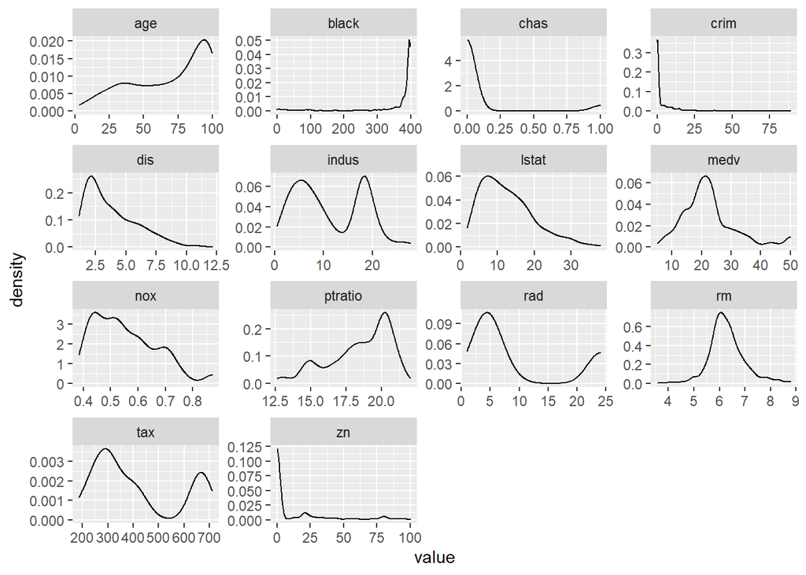

```r
# draw a bar plot of each variable

# we require dplyr, tidyr and ggplot for the below code chunk compiling the kernely densities
library(dplyr)
library(tidyr)
library(ggplot2)

gather(Boston) %>% ggplot(aes(value)) + geom_density() + facet_wrap("key", scales = "free")
```

We see that there is quite a lot of variability in terms of the suburbs in the Boston area. There are large differences in terms of the crime rate, the median value of the the houses, pollution, average count of rooms per apartment and even in the pupil to teacher ratio. By and large this looks quite promising in terms of ‘’profiling’’ the areas into distinct categories.

Yet we also observe that the variables are anything but normal, which is an issue for linear discriminant analysis.

Since we have a dataframe of mostly numeric and interval-valued variables, let us take a look at the pairwise Pearson correlation coefficients between the variables to see if some associations stand out.

```r
# We require the following libraries for the correlation plot
library(tidyr)
library(corrplot)
# calculate the correlation matrix and round it
cor_matrix <- Boston %>% cor() %>% round(digits=2)

# print the correlation matrix
cor_matrix
```

```
##          crim    zn indus  chas   nox    rm   age   dis   rad   tax ptratio
## crim     1.00 -0.20  0.41 -0.06  0.42 -0.22  0.35 -0.38  0.63  0.58    0.29
## zn      -0.20  1.00 -0.53 -0.04 -0.52  0.31 -0.57  0.66 -0.31 -0.31   -0.39
## indus    0.41 -0.53  1.00  0.06  0.76 -0.39  0.64 -0.71  0.60  0.72    0.38
## chas    -0.06 -0.04  0.06  1.00  0.09  0.09  0.09 -0.10 -0.01 -0.04   -0.12
## nox      0.42 -0.52  0.76  0.09  1.00 -0.30  0.73 -0.77  0.61  0.67    0.19
## rm      -0.22  0.31 -0.39  0.09 -0.30  1.00 -0.24  0.21 -0.21 -0.29   -0.36
## age      0.35 -0.57  0.64  0.09  0.73 -0.24  1.00 -0.75  0.46  0.51    0.26
## dis     -0.38  0.66 -0.71 -0.10 -0.77  0.21 -0.75  1.00 -0.49 -0.53   -0.23
## rad      0.63 -0.31  0.60 -0.01  0.61 -0.21  0.46 -0.49  1.00  0.91    0.46
## tax      0.58 -0.31  0.72 -0.04  0.67 -0.29  0.51 -0.53  0.91  1.00    0.46
## ptratio  0.29 -0.39  0.38 -0.12  0.19 -0.36  0.26 -0.23  0.46  0.46    1.00
## black   -0.39  0.18 -0.36  0.05 -0.38  0.13 -0.27  0.29 -0.44 -0.44   -0.18
## lstat    0.46 -0.41  0.60 -0.05  0.59 -0.61  0.60 -0.50  0.49  0.54    0.37
## medv    -0.39  0.36 -0.48  0.18 -0.43  0.70 -0.38  0.25 -0.38 -0.47   -0.51
##         black lstat  medv
## crim    -0.39  0.46 -0.39
## zn       0.18 -0.41  0.36
## indus   -0.36  0.60 -0.48
## chas     0.05 -0.05  0.18
## nox     -0.38  0.59 -0.43
## rm       0.13 -0.61  0.70
## age     -0.27  0.60 -0.38
## dis      0.29 -0.50  0.25
## rad     -0.44  0.49 -0.38
## tax     -0.44  0.54 -0.47
## ptratio -0.18  0.37 -0.51
## black    1.00 -0.37  0.33
## lstat   -0.37  1.00 -0.74
## medv     0.33 -0.74  1.00
```

We have quite high Pearson correlations between the variables. This seems in a sense intuitive, when looking at the variables measured, and their unidimensional distributions, which indicate that the suburbs in the Boston area are quite heterogeneous. High unidimensional variance makes room for meaningful correlation structures; the fact that one may posit that some values of features tend to go together, just by looking at what they measure (a simple example, say, pollution and industry), has one believe that such sructures will indeed emerge from our data.

From the perspective of urban studies, even if all of the suburbs of an area started out as relatively similar to each other, one would tend to get, through time, internally more and more homogeneous groups of suburbs, which, in turn, would tend to get less and less alike when looking at the differences between these groups having newly emerged. For what we often get is a mechanism of ‘’preferential attachment’‘, where alike attract alike, along a geographical accumulation of challenges, resulting in issues such as segregation, and polarization between the’‘good’’ and the ‘’bad’’ neighbourhoods.

To provide an illustrative if crass example: if one neighborhood had, initially, somewhat higher proportion of rich citizens, as a novel rich citizen contemplates moving from one suburb to another, or entirely from outside of the area and into it, he is, ceteris paribus, more likely to choose the area with a relatively high proportion of the rich. Moreover, the probability of choosing a given suburb might be directly proportional with the proportion of the wealthy already living in it. Then, as the process iterates, the proportion of the wealthy within that suburb grows ever larger, and along it increases also the probability of the wealthy moving in. This increases demand, and at some point the prizes of the suburb would climb to a level such that any further wealthy individual contemplating moving would start to favor an area with the second highest proportion of the wealthy instead, or perhaps prefer to move to a suburb adjacent to the wealthiest neighborhood. Thus, even if one had, at first, in absolute standards, relatively homogeneous suburbs by wealth, one would tend to get an increased variance of wealth across the suburbs through time, with clear clusters being formed by differences in wealth. Of course, wealth would then bring along with it other distinctive features to the neighborhood that are associated with wealth, resulting in a formation of multivariate clusters (say, some suburbs having high average income as well as low crime rates).

With that intro to the hypothesized dynamics to cluster formation in urban areas, let us look at a plot of the correlation matrix to see what pairwise profiles of suburbs in Boston pop out.

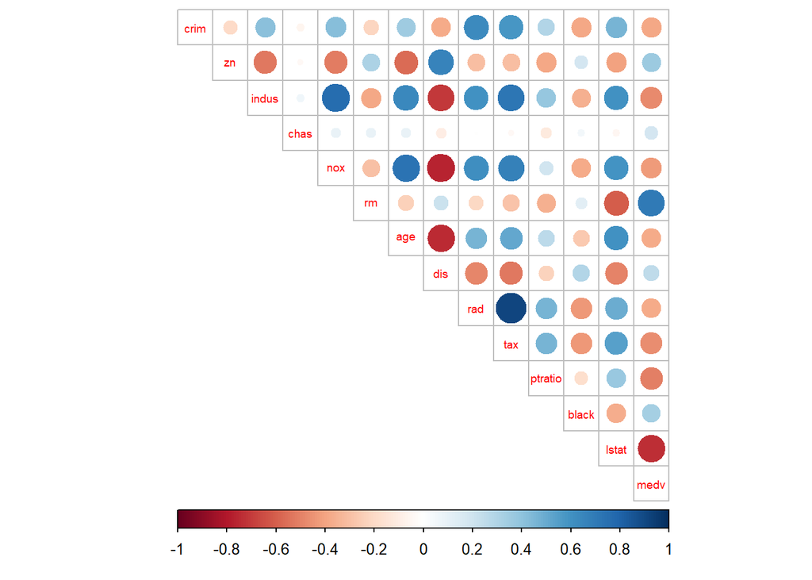

```r
# visualize the correlation matrix
corrplot(cor_matrix, method="circle", type="upper", cl.pos="b", tl.pos="d", tl.cex=0.6)
```

When looking at individual variables, we can see that ‘’indus’’ and ‘’nox’’ have particularly high absolute pairwise correlations with the rest of the variables, which is quite interesting, given the range of the content of the variables from educational issues to prizing and crime. ‘’Indus’’ and ‘’nox’’ also have a very high correlation between each other, which is unsurprising, since the former measures the amount of non-retail commercial ares (which I guess is mostly industry) and ‘’nox’’ pollution. We see that industrial areas are ones that are close to the highways, have high property tax rate and relatively high crime rates. The ‘’polluted’’ areas have similar profiles, since the correlation between industry and pollution is so high.

If we restrict our attention to the first row of the correlation matrix, since we are soon to delve more closely into the issue of crime, we may observe that the highest absolute correlations are with highway accessibility, industry, air pollution, proportion of ‘’low status’’ population and property tax rate. All these have a Pearson sample correlation coefficient of above 0.4.

## Standardization and other preprocessing prior to analysis

Let us standardize the data: subtract by the mean and divide by the standard deviation. This might be useful given the different variances and ranges to the variables. *If we did not scale*, large numerical distances would be found on the basis of those variables with high variance and range, even though such induced differences might not be large in the conceptual sense. On the contrary, when we are comparing observations on the standardized scale, we are interpreting ‘’large’’ in the appropriate context of the variable that accounts for the fact that different variables are measured on very different scales (even if they were all interval-scaled). A seemingly large difference of, say, 4, between observations in the original scale of a variable with a variance of 25, *ought by default not be considered as large as* a difference of 2 in terms of a variable with variance of 1 (this being reflected in the standardized scale, where the former amounts to a difference of 0.8 units of sd, and the the latter 2 units of sd). In short, without scaling, identified differences in terms of distances would tend to be driven by the absolute differences in the observations on those variables with high spread, even if such differences were not conceptually large or even noteworthy.

```r
# center and standardize variables
boston_scaled <- Boston %>% scale() %>% as.data.frame()

# summaries of the scaled variables
summary(boston_scaled)
```

```
##       crim                 zn               indus              chas
##  Min.   :-0.419367   Min.   :-0.48724   Min.   :-1.5563   Min.   :-0.2723
##  1st Qu.:-0.410563   1st Qu.:-0.48724   1st Qu.:-0.8668   1st Qu.:-0.2723
##  Median :-0.390280   Median :-0.48724   Median :-0.2109   Median :-0.2723
##  Mean   : 0.000000   Mean   : 0.00000   Mean   : 0.0000   Mean   : 0.0000
##  3rd Qu.: 0.007389   3rd Qu.: 0.04872   3rd Qu.: 1.0150   3rd Qu.:-0.2723
##  Max.   : 9.924110   Max.   : 3.80047   Max.   : 2.4202   Max.   : 3.6648
##       nox                rm               age               dis
##  Min.   :-1.4644   Min.   :-3.8764   Min.   :-2.3331   Min.   :-1.2658
##  1st Qu.:-0.9121   1st Qu.:-0.5681   1st Qu.:-0.8366   1st Qu.:-0.8049
##  Median :-0.1441   Median :-0.1084   Median : 0.3171   Median :-0.2790
##  Mean   : 0.0000   Mean   : 0.0000   Mean   : 0.0000   Mean   : 0.0000
##  3rd Qu.: 0.5981   3rd Qu.: 0.4823   3rd Qu.: 0.9059   3rd Qu.: 0.6617
##  Max.   : 2.7296   Max.   : 3.5515   Max.   : 1.1164   Max.   : 3.9566
##       rad               tax             ptratio            black
##  Min.   :-0.9819   Min.   :-1.3127   Min.   :-2.7047   Min.   :-3.9033
##  1st Qu.:-0.6373   1st Qu.:-0.7668   1st Qu.:-0.4876   1st Qu.: 0.2049
##  Median :-0.5225   Median :-0.4642   Median : 0.2746   Median : 0.3808
##  Mean   : 0.0000   Mean   : 0.0000   Mean   : 0.0000   Mean   : 0.0000
##  3rd Qu.: 1.6596   3rd Qu.: 1.5294   3rd Qu.: 0.8058   3rd Qu.: 0.4332
##  Max.   : 1.6596   Max.   : 1.7964   Max.   : 1.6372   Max.   : 0.4406
##      lstat              medv
##  Min.   :-1.5296   Min.   :-1.9063
##  1st Qu.:-0.7986   1st Qu.:-0.5989
##  Median :-0.1811   Median :-0.1449
##  Mean   : 0.0000   Mean   : 0.0000
##  3rd Qu.: 0.6024   3rd Qu.: 0.2683
##  Max.   : 3.5453   Max.   : 2.9865
```

Each of our variables now have a mean of zero and a standard deviation of 1. It is important to emphasize that the shapes to the kernels remain as before: clearly nonnormal.

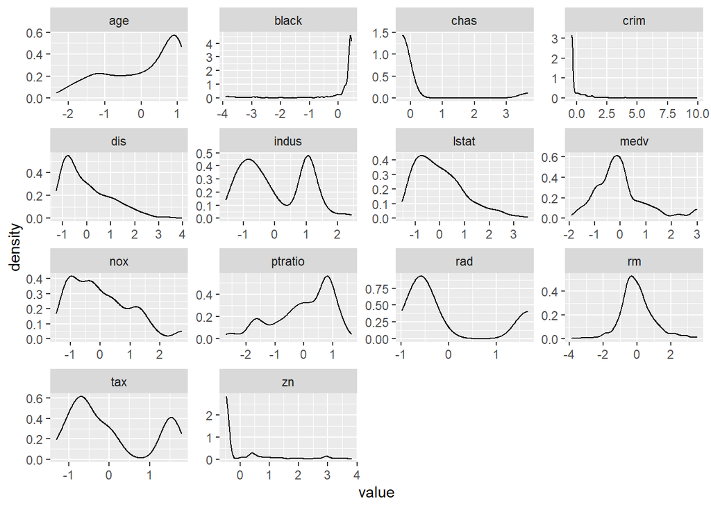

```r
# draw a bar plot of each variable
gather(boston_scaled) %>% ggplot(aes(value)) + geom_density() + facet_wrap("key", scales = "free")
```

We next turn the crime rate into a factor by utilizing the quartiles as the cut-off points for each level of the factor. We also remove the old crime variable and insert the novel factor into our dataframe.

```r
# create a quantile vector of crim and print it
bins <- quantile(boston_scaled$crim)

# create a categorical variable 'crime'
crime <- cut(boston_scaled$crim, breaks = bins, include.lowest = TRUE, labels=c("low", "med_low", "med_high", "high"))

# remove original crim from the dataset
boston_scaled <- dplyr::select(boston_scaled, -crim)

# add the new categorical value to scaled data
boston_scaled <- data.frame(boston_scaled, crime)

# look at the table of the new factor crime
table(crime)
```

```
## crime
##      low  med_low med_high     high
##      127      126      126      127
```

Having used quartiles as the cut-off points, we have groups of the same size, which will be handy for linear discriminant analysis. The names for the levels are in an ascending order of the crime rate.

We then divide our dataframe into a training and a test dataset, so that a random 80% of the rows go into the first and the rest to the second dataset.

```r
# number of rows in the Boston dataset
n <- nrow(boston_scaled)

set.seed(13)

# choose randomly 80% of the rows
ind <- sample(n,  size = n * 0.8)

# create train set
train <- boston_scaled[ind,]

# create test set
test <- boston_scaled[-ind,]

# save the correct classes from test data
correct_classes <- test$crime

# remove the crime variable from test data
test <- dplyr::select(test, -crime)
```

## Identifying the level of the crime factor with linear discriminant analysis

*Even though our predictors our anything but normally distributed*, we next fit linear discrimant analysis to the dataset, using the crime factor variable as the predicted class and the rest of the dataset as predictors to the class.

```r
set.seed(13)

# linear discriminant analysis
lda.fit <- lda(crime~., data = train)

# print the lda.fit object
lda.fit
```

```
## Call:
## lda(crime ~ ., data = train)
##
## Prior probabilities of groups:
##       low   med_low  med_high      high
## 0.2500000 0.2425743 0.2500000 0.2574257
##
## Group means:
##                  zn      indus        chas        nox          rm        age
## low       1.0387189 -0.9767339 -0.07742312 -0.9069312  0.42495894 -0.9610733
## med_low  -0.1505672 -0.2741192 -0.03128211 -0.5232661 -0.17044394 -0.2322348
## med_high -0.4099764  0.2163751  0.27340760  0.4081463  0.03035225  0.4361659
## high     -0.4872402  1.0170690 -0.04518867  1.0673319 -0.34504206  0.8466357
##                 dis        rad        tax    ptratio       black       lstat
## low       0.9716949 -0.6839520 -0.7187624 -0.4692634  0.37666578 -0.75944749
## med_low   0.2196880 -0.5541258 -0.4786835 -0.0275366  0.31157562 -0.08476445
## med_high -0.3804549 -0.4065006 -0.2926143 -0.2538600  0.05994208  0.03839268
## high     -0.8621139  1.6386213  1.5144083  0.7813507 -0.79744136  0.95896029
##                 medv
## low       0.49895878
## med_low  -0.02919621
## med_high  0.11065317
## high     -0.70581567
##
## Coefficients of linear discriminants:
##                 LD1         LD2          LD3
## zn       0.06730671  0.72287941 -0.677952513
## indus    0.01284008 -0.33836495  0.227548425
## chas    -0.08008875 -0.07027516  0.005438349
## nox      0.40439038 -0.42138772 -1.626337373
## rm      -0.10631135 -0.02058266 -0.172746305
## age      0.31076921 -0.47152796 -0.105698304
## dis     -0.04654913 -0.14471928 -0.333792125
## rad      3.15924739  0.84542009  0.093315372
## tax      0.02473731  0.08339073  0.382334733
## ptratio  0.10350540  0.08612476 -0.231180070
## black   -0.11571284 -0.01011184  0.099358292
## lstat    0.24418102 -0.12223021  0.211722225
## medv     0.22199933 -0.26865999 -0.367808096
##
## Proportion of trace:
##    LD1    LD2    LD3
## 0.9452 0.0434 0.0114
```

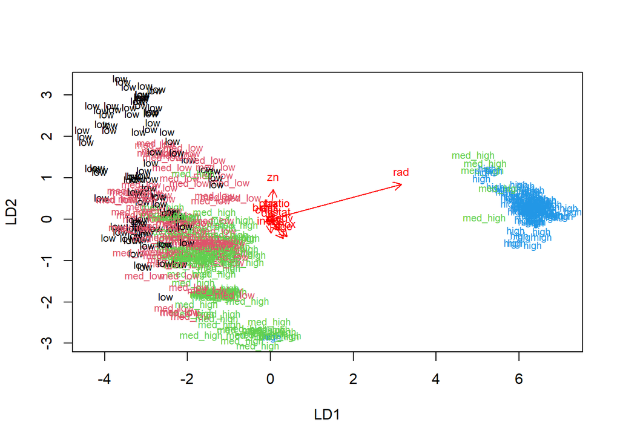

```r
# the function for lda biplot arrows
lda.arrows <- function(x, myscale = 1, arrow_heads = 0.1, color = "red", tex = 0.75, choices = c(1,2)){
  heads <- coef(x)
  graphics::arrows(x0 = 0, y0 = 0,
         x1 = myscale * heads[,choices[1]],
         y1 = myscale * heads[,choices[2]], col=color, length = arrow_heads)
  text(myscale * heads[,choices], labels = row.names(heads),
       cex = tex, col=color, pos=3)
}

# target classes as numeric
classes <- as.numeric(train$crime)

# plot the lda results (select both lines and execute them at the same time!)
plot(lda.fit, dimen = 2, col = classes, pch = classes)
lda.arrows(lda.fit, myscale = 1)
```

## Predicting the level of the crime factor with linear discriminant analysis

So it would seem on the basis of the visual plot that our linear discriminant analysis holds promise in terms of predicting crime factor levels. We may evaluate the fit more closely by looking at how well our model predicts the classes of the test dataset on which it has not been fitted. Our test set has 102 observations.

```r
# predict classes with test data
lda.pred <- predict(lda.fit, newdata = test)

# cross tabulate the results
table(correct = correct_classes, predicted = lda.pred$class)
```

```
##           predicted
## correct    low med_low med_high high
##   low       10      12        4    0
##   med_low    9      16        3    0
##   med_high   2       7       15    1
##   high       0       0        0   23
```

We have seem to have quite good classification performance: with the correct predictions found on the diagonal, we have a sum total of 64, which comes down to an accuracy of $64/102\sim=0.628$.With a balanced baseline, so that all classes are of the same size, without our predictors and our model, we would have an accuracy of $0.25$. Compared to that our model classifies relatively well.

We get the ‘’high’’ class correctly predicted especially well, with all observations of the test set belonging to that category being classified correctly. It proves more difficult for us to make the distinctions for the two low-groups than the two high groups (as we detected already from our visual): when the correct class is low, we get our prediction correct with proportion $10/26=0.385$, with $12$ observations predicted to the med_low category; when the correct class is med_low, we get our prediction correct $16/28=0.571$ of the time, with 12 incorrectly predicted in the low or the med_high category.

This means that we would be better able to classify observations into fewer classes: or, to put it differently, it seems there is relatively little in our features that would allow us to distinguish between the suburbs with low and med_low crime rates, whereas we are better at distinguishing between the two low categories and the two high categories. We are especially apt at identifying the high crime rate suburbs. These suburbs are apparently characterized by features that they very much share with each other but which the other classes of suburbs do not have.

## K-means clustering

```r
# Rescale Boston dataset and retain its type as a data.frame object
Boston_scaled2<-as.data.frame(scale(Boston))

# Euclidean distance matrix
dist_eu <- dist(Boston_scaled2)

# look at the summary of the distances
summary(dist_eu)
```

```
##    Min. 1st Qu.  Median    Mean 3rd Qu.    Max.
##  0.1343  3.4625  4.8241  4.9111  6.1863 14.3970
```

```r
# manhattan distance matrix
dist_man <- dist(Boston, method="manhattan")

# look at the summary of the distances
summary(dist_man)
```

```
##     Min.  1st Qu.   Median     Mean  3rd Qu.     Max.
##    2.016  149.145  279.505  342.899  509.707 1198.265
```

We then run the K-means clustering algorithm, first with four clusters. We print the clusters as functions of the predictors. Since there are 14 predictors, we split the visuals into three partitions of the variables.

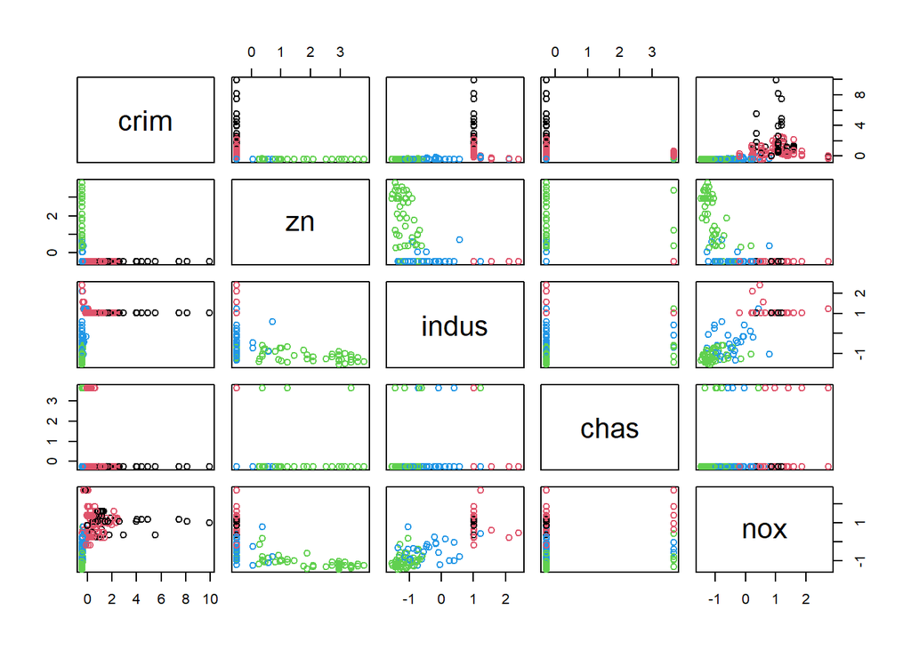

```r
# Set seed for reproducibility
set.seed(123)

# k-means clustering
km <- kmeans(Boston_scaled2, centers = 4)

# plot the Boston dataset with clusters, variables 1 to 5
pairs(Boston_scaled2[1:5], col = km$cluster)
```

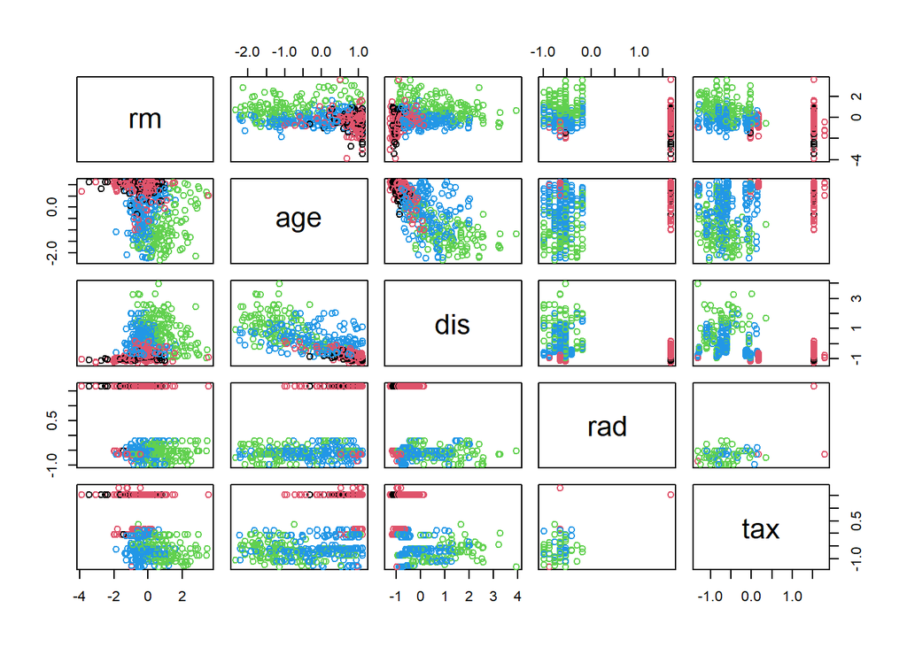

```r
# plot the Boston dataset with clusters, variables 6 to 10
pairs(Boston_scaled2[6:10], col = km$cluster)
```

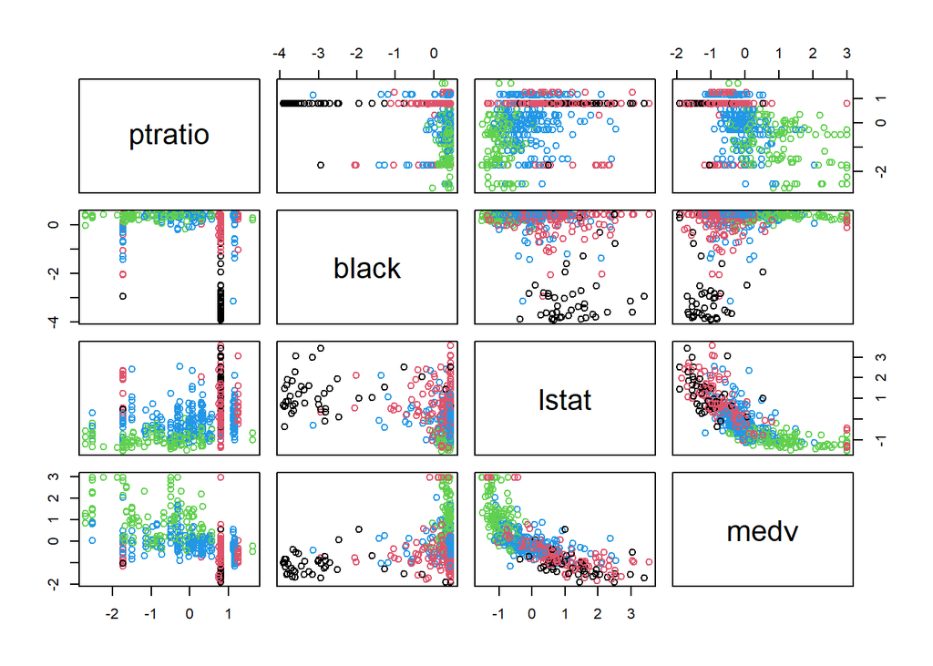

```r
# plot the Boston dataset with clusters, variables 10 to 15
pairs(Boston_scaled2[11:14], col = km$cluster)
```

We note from the two-dimensional visuals of the clusters that while we have an ability to distinguish the clusters, these tend to overlap, with the possible exception of the cluster colored in black. This cluster can be distinguished from the others pretty well in terms of a low value measured on the variable ‘’black’’.